# R markdown: PDF, Word, and more

Sébastien Renaut

2018-09-06

# Outputs

- We can output the same information in different ways
  - *.Rmd*: The `R markdown` document.
  - *.html*: A webpage.
  - *.docx*: A MS Word document.
  - *.tex*: A [LaTeX](https://www.latex-project.org) document.
  - *.pdf*: A Portable Document Format.

# 1 html document

```html
---
title: "rmarkdown_pdf"
author: "Sébastien Renaut"
date: '2018-09-06'
output:
  html_document:
    toc: yes
    theme: cerulean
---
```

- You can specify it when you create a new `Rmarkdown` document.
- You can also specify it later in the header.
- Then, it’s just a matter of kniting the document!

# 2 Microsoft Word

```
---
title: "rmarkdown_docx"
author: "Sébastien Renaut"
date: '2018-09-06'
output:
  word_document:
    toc: yes
---
```

- Little documentation, few options & configurations are possible (This is probably not the format that should be promoted, as it moves away from an open source environment).
- Can specify a [LibreOffice](https://www.libreoffice.org/) OpenDocument Text (`output: odt_document`) or Rich Text Format (`output: rtf_document`) instead.
- FYI, there is a spellchecker in `Rstudio`: Edit >Check Spelling…

# 3 Portable Document Format (.pdf)

```
---
title: "rmarkdown_pdf"
author: "Sébastien Renaut"
date: '2018-09-06'
output:
  pdf_document:
    keep_tex: true
    toc: yes
---
```

- You need an extra step to go from a LaTeX (*.tex*) format to a *.pdf*. This is handled by the `R tinytex pdflatex` function in R.

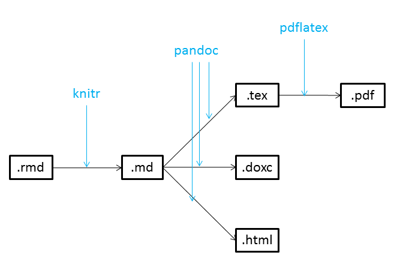

## 3.1 LaTeX

- [LaTeX software](https://www.latex-project.org) is a high-quality typesetting system.
- It is the *de facto* standard for the communication and publication of scientific documents.
- LaTeX is available as a [free software](https://www.latex-project.org/get/).
- If interested, follow this discussion: [*Why LaTeX is such a bloated system?*](https://ubuntuforums.org/showthread.php?t=395863)
- So…[*TinyTeX*](https://yihui.name/tinytex/r/)
  - A custom LaTeX distribution that is small in size (~150MB) but functions well in most cases, especially for `R` users .
  - `tinytex` is an R studio package that installs *TinyTeX*.
- You should now have all the tools to generate your fully reproducible manuscripts in `R`!

# 4 Exercice 1

- If you haven’t done so, install the `tinytex` R package from the console and run `install_tinytex()` to install *TinyTeX* (It may take a few minutes to download and compile, ~150MB).

```
install.packages("tinytex")
library(tinytex)
install_tinytex()
```

- Create a new document, compile it as *.pdf*.
  - Add a Table of Content.
  - Add a graphic.
- Now compile it as a Word document (*.docx*)
- Add some references by specifying the `csl` (eg. csl : ../csl/peerj.csl) and `bibliography` (eg. bibliography : ../biblio/test_library.bib in the header.

# 5 Further customization

## 5.1 `rticles`

- R packages `rticles` is a (potentially) useful package to format articles according to the specification of a journal.

```
install.packages("rticles")
```

- Once installed, you can start a new R markdown document according to your journal of interest.

[figure not shown]

[figure not shown]

- Right now, few templates available.
- Some templates may be slower to render, depending on what *LaTeX* package need to be installed.

## 5.2 LaTeX template: manuscript

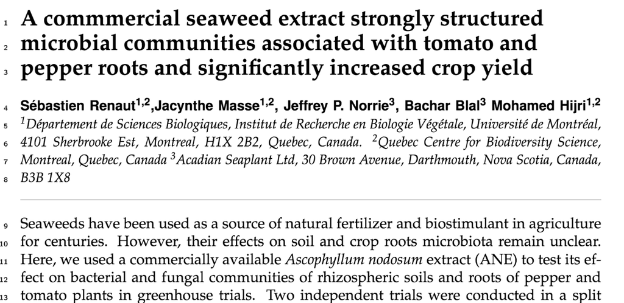

  - The only real objection I see against writing manuscript in `R markdown` is integrating the comments of co-authors.

## 5.3 LaTeX template: CV

- Here is a template I like for [*Curriculum Vitae*](https://github.com/svmiller/svm-r-markdown-templates/blob/master/svm-latex-cv.tex)
  - For example, using this template, I re-wrote my [CV](http://sebastien.renaut.com/wp-content/uploads/2019/02/cv.pdf) to give it a fresh look!

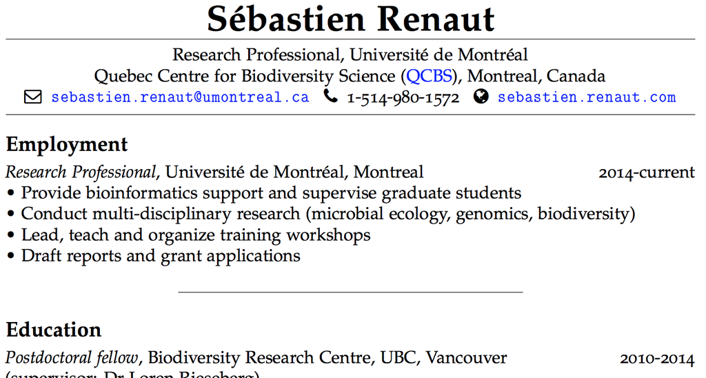

- Let’s briefly examine and knit the *svm-rmarkdown-cv.Rmd* file in the reference_material directory.

# 6 Presentations

```
---
title: "Untitled"
author: "Sebastien Renaut"
date: "27/02/2019"
output: ioslides_presentation
---
```

- You can also generate Powerpoint-like presentations.

[figure not shown]

# 7 Bookdown

- [Bookdown](https://bookdown.org/) is an open-source R package that facilitates writing books and long-form articles/reports with R Markdown.

[figure not shown]